# Object Oriented Programming in R

Statistics 506, Fall 2020

## Object Oriented Programming

When we attach values to names in an **R** environment we generally refer to the name and value collectively as an ‘object’. More formally, we can distinguish between *base objects* and *object-oriented objects* where the latter are those with a non-null class attribute. Compare the following:

```r
# A base object with NULL class attribute
attr(1:5, 'class')
```

[output not shown]

```r
# An object of class factor.
attr(factor(1:5), 'class')
```

```
## [1] "factor"
```

[Object oriented programming](https://en.wikipedia.org/wiki/Object-oriented_programming) is a programming paradigm built around the notions of classes, methods, and, of course, objects. There are a wide variety of object oriented languages and R has (at least) three *object oriented* (OO) systems you should be aware of:

1. S3 - R’s original, informal OOP system;
2. S4 - a more formal less flexible version of S3;
3. RC - a reference class OOP system that more closely resembles the encapsulated object paradigm used in languages like C++ and Python.

We will focus on the S3 and S4 systems which predominate in R. You can read about RC and the related R6 system in **Advanced R**.

Before digging into R’s OO systems it will be helpful to define a few terms.

- An object’s **class** defines its structure and behavior using *attributes* and its relationship with other classes.
- **Methods** are functions that have definitions which depend on the class of an object.
- Classes are often organized into hierarchies with a “child” class defined more strictly than any “parents”. Child classes often **inherit** from any parents. This means a parent’s structure or methods serve as a default when not explicitly defined for the child. More formally, these are known as **superclasses** and **subclasses**.

## Reading

- [“Object Oriented Programming”](https://adv-r.hadley.nz/oo.html): read the section introduction, and chapters 12, 13, and 15 in *Advanced R*.
- *Programmer’s Niche: A simple class, in S3 and S4* by Thomas Lumley on page 33 at this [link](https://cran.r-project.org/doc/Rnews/Rnews_2004-1.pdf).

## The S3 system in R

The S3 system in **R** is based on the idea of **generic functions**.  
The core idea is that a **generic function** is used to **dispatch** a **class-specific method** taken from an object passed to it.

Some common S3 generic functions in **R** include: `print`, `summary`, `plot`, `mean`, `head`, `tail`, and `str`. If we look at the definitions for these functions, we see they are all quite simply defined in terms of a call to `UseMethod()`.

```r
print
```

```
## function (x, ...)
## UseMethod("print")
## <bytecode: 0x7fef28107be8>
## <environment: namespace:base>
```

```r
summary
```

```
## function (object, ...)
## UseMethod("summary")
## <bytecode: 0x7fef265e78a8>
## <environment: namespace:base>
```

```r
head
```

```
## function (x, ...)
## UseMethod("head")
## <bytecode: 0x7fef265a0538>
## <environment: namespace:utils>
```

```r
UseMethod
```

```
## function (generic, object)  .Primitive("UseMethod")
```

When `UseMethod()` is called **R** searches for an S3 method based on the name of the generic function and the class of its first argument. The specific function it looks for follows the naming pattern `generic.class` – this is why it is advisable not to use dots when naming functions, classes, or other objects unless explicitly defining an S3 method.

### S3 Example

As an example, let’s construct a matrix object `mat` and examine a call to `head(mat)`:

```r
mat = matrix(1:45, nrow = 9, ncol = 5)
class(mat)
```

```
## [1] "matrix" "array"
```

```r
head(mat)
```

```
##      [,1] [,2] [,3] [,4] [,5]
## [1,]    1   10   19   28   37
## [2,]    2   11   20   29   38
## [3,]    3   12   21   30   39
## [4,]    4   13   22   31   40
## [5,]    5   14   23   32   41
## [6,]    6   15   24   33   42
```

The object `mat` has classes `matrix` and `array`. Therefore, `UseMethod("head")` searches for a function (or method) called `head.matrix()` to apply to `mat`:

```r
head.matrix
```

```
## function (x, n = 6L, ...)
## {
##     checkHT(n, d <- dim(x))
##     args <- rep(alist(x, , drop = FALSE), c(1L, length(d), 1L))
##     ii <- which(!is.na(n[seq_along(d)]))
##     args[1L + ii] <- lapply(ii, function(i) seq_len(if ((ni <- n[i]) <
##         0L) max(d[i] + ni, 0L) else min(ni, d[i])))
##     do.call("[", args)
## }
## <bytecode: 0x7fef2475ed50>
## <environment: namespace:utils>
```

We can describe this sequence using a call tree:

$$\texttt{head(mat)} \to \texttt{UseMethod("head")} \to
\texttt{.Primitive("UseMethod")} \to \texttt{head.matrix(mat)}.$$

S3 methods always work by this pattern: *generic* $\to$ *dispatch* $\to$ *method*.

### Finding S3 methods

You can see all the methods associated with a generic function using `methods()`.

```r
methods(head)
```

```
## [1] head.array*      head.data.frame* head.default*    head.ftable*
## [5] head.function*   head.matrix
## see '?methods' for accessing help and source code
```

The `*` following some methods is used to denote methods that are not exported as part of the namesapce of the packages in which they are defined. For instance, the `head.data.frame` method is defined in the (base) package `utils`, but is not exported.

```r
getS3method('head', 'data.frame')
```

```
## function (x, n = 6L, ...)
## {
##     checkHT(n, d <- dim(x))
##     args <- rep(alist(x, , drop = FALSE), c(1L, length(d), 1L))
##     ii <- which(!is.na(n[seq_along(d)]))
##     args[1L + ii] <- lapply(ii, function(i) seq_len(if ((ni <- n[i]) <
##         0L) max(d[i] + ni, 0L) else min(ni, d[i])))
##     do.call("[", args)
## }
## <bytecode: 0x7fef266283a8>
## <environment: namespace:utils>
```

When an object has more than one class, **R** searches successively through the class attribute until a suitable method is found. The `sloop` package and its function `s3_dispatch()` are helpful for understanding how this works.

Here is an example:

```r
class(mat) = c('green', class(mat))
class(mat)
```

```
## [1] "green"  "matrix" "array"
```

```r
head(mat)
```

```
##      [,1] [,2] [,3] [,4] [,5]
## [1,]    1   10   19   28   37
## [2,]    2   11   20   29   38
## [3,]    3   12   21   30   39
## [4,]    4   13   22   31   40
## [5,]    5   14   23   32   41
## [6,]    6   15   24   33   42
```

```r
sloop::s3_dispatch(head(mat))
```

```
##    head.green
## => head.matrix
##  * head.array
##  * head.default
```

If a suitable method is not found, S3 generics revert to a default method when defined and throw an error if not. We can call some methods explicitly:

```r
head.matrix(mat)
```

```
##      [,1] [,2] [,3] [,4] [,5]
## [1,]    1   10   19   28   37
## [2,]    2   11   20   29   38
## [3,]    3   12   21   30   39
## [4,]    4   13   22   31   40
## [5,]    5   14   23   32   41
## [6,]    6   15   24   33   42
```

but others such as `head.default` are not exposed as discussed above.

You can view the source code for unexposed S3 generics using `getS3method('generic', 'class')`.

```r
getS3method('head', 'default')
```

```
## function (x, n = 6L, ...)
## {
##     checkHT(n, dx <- dim(x))
##     if (!is.null(dx))
##         head.array(x, n, ...)
##     else if (length(n) == 1L) {
##         n <- if (n < 0L)
##             max(length(x) + n, 0L)
##         else min(n, length(x))
##         x[seq_len(n)]
##     }
##     else stop(gettextf("no method found for %s(., n=%s) and class %s",
##         "head", deparse(n), sQuote(class(x))), domain = NA)
## }
## <bytecode: 0x7fef253a74c0>
## <environment: namespace:utils>
```

Once you know the package namespace within which a method is defined you can call it explicitly using, e.g. `utils:::head.default()`.

### Defining S3 methods

Defining a new S3 method is as simple as defining a function and naming it accordingly. Here we define a method `head.green()`.

```r
head.green = function(obj) {

  # Green escape sequences, from e.g. crayon::green("green").
  g1 = '\033[32m'
  g2 = '\033[39m'

  # Make sure obj is an object
  if ( !is.object(obj) ) warning("Object 'obj' is not an object!")

  # Check if its green
  if ('green' %in% class(obj) ) {
    if ( length(class(obj)) > 1 ) {
      next_class = class(obj)[-grep('green', class(obj))][1]
      cat( sprintf('This is a %sgreen %s%s.\n', g1, next_class, g2) )

      # This calls the next available method, allowing us to offload work in
      # a method for the subclass to an existing method for the superclass.
      NextMethod("head")

    } else {
      cat(sprintf('This a %sgeneric green object%s.\n', g1, g2))
    }
  } else {
    cat(sprintf('The object is not %sgreen%s!\n', g1, g2))
  }

}
```

Now we can test it under various conditions.

```r
## We previously assigned
class(mat)
```

```
## [1] "green"  "matrix" "array"
```

```r
head(mat)
```

```
## This is a green matrix.
```

```
##      [,1] [,2] [,3] [,4] [,5]
## [1,]    1   10   19   28   37
## [2,]    2   11   20   29   38
## [3,]    3   12   21   30   39
## [4,]    4   13   22   31   40
## [5,]    5   14   23   32   41
## [6,]    6   15   24   33   42
```

```r
## Test head.green for generic class
class(mat) = 'green'
head(mat)
```

```
## This a generic green object.
```

```r
## Test on a non-green object
red_obj = 1:100
class(red_obj) = 'red'
head.green(red_obj)
```

```
## The object is not green!
```

```r
head(red_obj)
```

```
## [1] 1 2 3 4 5 6
```

In our definition of `head.green`, notice the use of `NextMethod()` to dispatch a method previously defined on one of the parent classes.

### Defining S3 Generics

We can similarly define our own S3 generic functions via `UseMethod()`.

Note that the first argument to both `UseMethod()` and `NextMethod()` should be a character vector with the name of the generic.

```r
# Generic Color finder
getColor = function(obj) {
  UseMethod("getColor")
}

# Default method
getColor.default = function(obj) {
  # Are any classes colors?
  ind = class(obj) %in% colors()
  if ( any(ind) ) {
     # Yes. Return color with highest class predence.
     class(obj)[which(ind)[1]]
  } else {
    # No return a random color.
    sample(colors(), 1)
  }
}

# Specific method aliasing green to "darkgreen"
getColor.green = function(obj) {
  "darkgreen"
}
```

As a quick, somewhat contrived, example of how we might use this, we could define a `col_boxplot` function to pick colors according to the class of the object passed.

```r
# A box plot function that uses the class attribute to define colors.
col_boxplot = function(dat, ...) {
  if ( is.atomic(dat) ) {
    boxplot(dat, col = getColor(dat), ...)
  } else{
    col = sapply(dat, getColor)
    boxplot(dat, col = col, ...)
  }
}
```

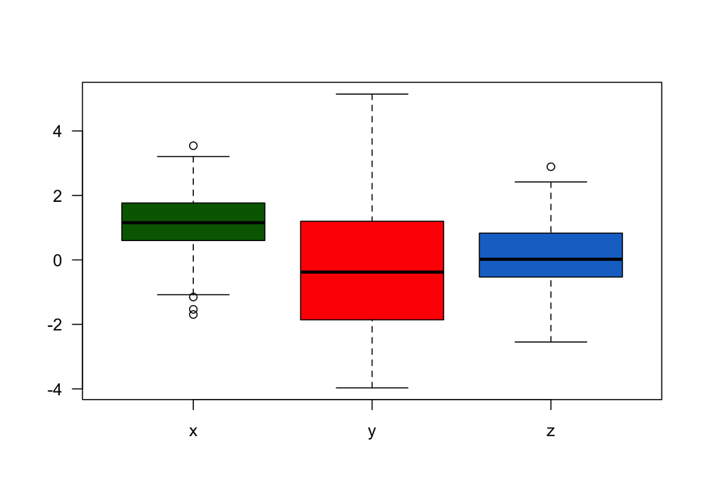

```r
# Define some iid data
x = rnorm(100, 1, 1); class(x) = 'green'
y = rnorm(100, 0, 2); class(y) = 'red'
z = rnorm(100, 0, 1)
col_boxplot(list(x = x, y = y, z = z), las = 1)
```

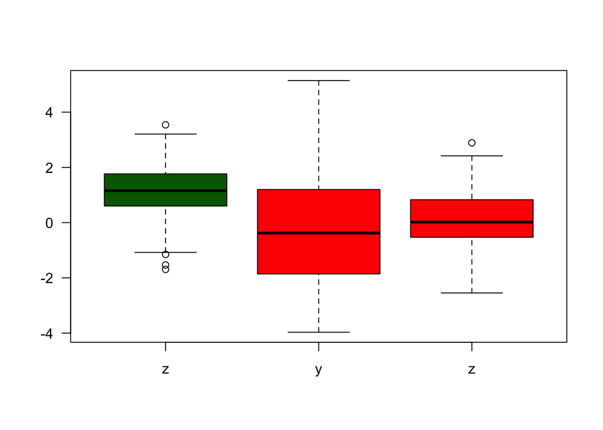

```r
col_boxplot(list(z = x, y = y, z = z), las = 1)
```

### Caution

You should be aware that the class of the object returned by some generic functions (especially primitives) can depend on the input class.

```r
class(x + y)
```

```
## [1] "green"
```

```r
class(y + x)
```

```
## [1] "red"
```

```r
class(mean(x))
```

```
## [1] "numeric"
```

### Defining an S3 class

There are four common “styles” of S3 object:

1. **vector** style S3 objects include the `factor` and `Date` classes which are built on atomic vectors and use attributes to add additional structure,
2. **scalar** style S3 objects use a list to describe aspects of a single thing, e.g. the `lm` and `glm` classes,
3. a **record** style S3 object such as used for the `POSIXlt` class has a fixed set of elements all of equal lengths that represent aspects of each datum,
4. a **data.frame** style objects are similarly lists with components of equal lengths, but these elements of arbitrary rather than fixed classes.

The majority of S3 objects you will encounter are in the **scalar style** – they are simply lists with a class attribute governing method dispatch.

As an example, consider the class `lm` returned by the `lm()` function for linear regression modeling. We can find the definition of an `lm` object in the R [documentatation](https://www.rdocumentation.org/packages/stats/versions/3.6.1/topics/lm).

## The S4 System

The S3 system described above is very flexible making it easy to work with, but at the expense of the safety and uniformity of a more formal OO system.

The S4 system is a more formal OO system in R. One key difference is that S4 classes have formal definitions and classes, methods, and generics must all be explicitly defined as such. The functionality of the S4 object system comes from the (base) “methods” package.

### Defining an S4 class

S4 classes are defined using the `setClass` function:

```r
setClass("color_vector",
   slots = c(
     name = 'character',
     data = 'numeric',
     color = 'character'
   )
)
```

Create a new instance of an S4 class using `new`:

```r
x = new("color_vector", name = "x", color = "darkgreen")
x
```

```
## An object of class "color_vector"
## Slot "name":
## [1] "x"
##
## Slot "data":
## numeric(0)
##
## Slot "color":
## [1] "darkgreen"
```

The function `new` is used above as a *constructor* for creating an object with the desired class. Most S4 classes defined in packages you download have their own constructors which you should use when defined. We can create a default constructor by assigning the output of `setClass` a name:

```r
color_vector =
 setClass("color_vector",
   slots = c(
     name = 'character',
     data = 'numeric',
     color = 'character'
   )
 )
y = color_vector(name = "y", data = rnorm(100, 0, 2), color = "red")
class(y)
```

```
## [1] "color_vector"
## attr(,"package")
## [1] ".GlobalEnv"
```

You could also create an explicit constructor by writing a function that calls `new` and manipulates the object in some way, say providing defaults for attributes.

### Accessing slots in an S4 object

You can access and set attributes for an S4 object using an `@` symbol, the `slot` function, or an `attr(obj, 'name')` construction:

```r
## Access slots using @
x@color
```

```
## [1] "darkgreen"
```

```r
# Assign some data to the data slot
x@data = rnorm(10, 1, 1)

# Check the color
slot(x, 'color')
```

```
## [1] "darkgreen"
```

```r
# Change the name of x
attr(x, 'name') = 'Green Values'
names(attributes(x))
```

```
## [1] "name"  "data"  "color" "class"
```

Only the first `slot(obj, 'name')` and last `attr(obj, 'name')` work for S3 objects.

```r
s3 = factor(1:10, levels = 1:10, labels = letters[1:10])
attr(s3, "levels")
```

```
##  [1] "a" "b" "c" "d" "e" "f" "g" "h" "i" "j"
```

```r
slot(s3, "levels")
```

```
##  [1] "a" "b" "c" "d" "e" "f" "g" "h" "i" "j"
```

```r
tryCatch({ s3@levels }, error = identity)
```

```
## <simpleError in doTryCatch(return(expr), name, parentenv, handler): trying to get slot "levels" from an object (class "factor") that is not an S4 object >
```

In addition, authors of S4 classes often provide accessor functions to get at the most common slots. Here is an example:

```r
color = function(obj) {
 # Accessor function for the "color" slot in the color_vector class
 # Inputs: obj - an object of class color vector
 # Returns: the value of the color slot
 # If the object is not of class color vector, a random color is returned with
 # a warning.

 y = as.character(match.call())
 if ( !{"color_vector" %in% class(obj) } ) {
   msg = sprintf('Object %s is not of class color_vector.\n', y[2] )
   warning(msg)
   return( sample(colors(), 1) )
 }

 slot(obj, 'color')

}
color(x)
```

```
## [1] "darkgreen"
```

```r
color(y)
```

```
## [1] "red"
```

```r
color(LETTERS)
```

```
## [1] "deepskyblue3"
```

### Validator

A validator is a function that ensures an object is a valid member of a given class. Here is an example validator for our `color_vector` class.

```r
setValidity("color_vector", function(object) {
  if ( !{object@color %in% colors()} ) {
    sprintf('@color = %s is not a valid color. See colors().', object@color)
  } else {
    TRUE
  }
})
```

```
## Class "color_vector" [in ".GlobalEnv"]
##
## Slots:
##
## Name:       name      data     color
## Class: character   numeric character
```

```r
tryCatch({color_vector(name = 'test', data = 1:3, color = 'A')},
         error = identity)
```

```
## <simpleError in validObject(.Object): invalid class "color_vector" object: @color = A is not a valid color. See colors().>
```

### S4 Methods

We can control how an object of class `color_vector` gets displayed by defining a `show` method (the S4 equivalent of `print`).

```r
## This is an S4 generic
show(x)
```

```
## An object of class "color_vector"
## Slot "name":
## [1] "Green Values"
##
## Slot "data":
##  [1]  2.0793072  1.1020231  0.0194862  0.4737538  1.2446874  1.1115460
##  [7]  2.4734511  0.3636716 -1.2003157 -0.3708521
##
## Slot "color":
## [1] "darkgreen"
```

```r
## Change how color_vector objects are shown.
setMethod('show', 'color_vector',
  function(object) {
    msg = sprintf('name: %s, color: %s\n\n', object@name, object@color)
    cat(msg)
    cat('Data:')
    str(object@data)
    cat('\n')
  }
)
```

Now, when we call `show` on an object of class `color_vector` **R** will use the custom method.

```r
show(x)
```

```
## name: Green Values, color: darkgreen
##
## Data: num [1:10] 2.0793 1.102 0.0195 0.4738 1.2447 ...
```

```r
# Note: show, like print, is the default method for an unassigned object.
x
```

```
## name: Green Values, color: darkgreen
##
## Data: num [1:10] 2.0793 1.102 0.0195 0.4738 1.2447 ...
```

We could similarly define a method that allows the user to change the value in the color slot. This is a so-called “setter” function.

```r
## Define a new accessor for setting the color
setGeneric("color<-", function(object, value) standardGeneric('color<-'))
```

```
## [1] "color<-"
```

```r
setMethod('color<-', 'color_vector',
  function(object, value) {
    object@color = value
    validObject(object)
    object
  }
)

color(x) = 'purple'
color(x)
```

```
## [1] "purple"
```

```r
show(x)
```

```
## name: Green Values, color: purple
##
## Data: num [1:10] 2.0793 1.102 0.0195 0.4738 1.2447 ...
```

## Resources

- “Object Oriented Programming” (chapter 9) in Norman Matloff’s *The Art of R Programming*.
- [The R Language](http://dept.stat.lsa.umich.edu/~kshedden/Courses/Stat506/r_language/) from Professor Shedden’s 2016 course notes.
- The [R6 package](https://github.com/r-lib/R6/) provides `C++` style classes in R.